# Assignment 4 - Average Reward Softmax Actor-Critic

Welcome to your Course 3 Programming Assignment 4. In this assignment, you will implement **Average Reward Softmax Actor-Critic** in the Pendulum Swing-Up problem that you have seen earlier in the lecture. Through this assignment you will get hands-on experience in implementing actor-critic methods on a continuing task.

**In this assignment, you will:**

```
1. Implement softmax actor-critic agent on a continuing task using the average reward formulation.
2. Understand how to parameterize the policy as a function to learn, in a discrete action environment.
3. Understand how to (approximately) sample the gradient of this objective to update the actor.
4. Understand how to update the critic using differential TD error.
```

## Pendulum Swing-Up Environment

In this assignment, we will be using a Pendulum environment, adapted from [Santamaría et al. (1998)](http://www.incompleteideas.net/papers/SSR-98.pdf). This is also the same environment that we used in the lecture. The diagram below illustrates the environment.

[figure not shown]

The environment consists of single pendulum that can swing 360 degrees. The pendulum is actuated by applying a torque on its pivot point. The goal is to get the pendulum to balance up-right from its resting position (hanging down at the bottom with no velocity) and maintain it as long as possible. The pendulum can move freely, subject only to gravity and the action applied by the agent.

The goal is to swing-up the pendulum and maintain its upright angle. Hence, the reward is the negative absolute angle from the vertical position: $R_{t} = -|\beta_{t}|$

Furthermore, since the goal is to reach and maintain a vertical position, there are no terminations nor episodes. Thus this problem can be formulated as a continuing task.

Similar to the Mountain Car task, the action in this pendulum environment is not strong enough to move the pendulum directly to the desired position. The agent must learn to first move the pendulum away from its desired position and gain enough momentum to successfully swing-up the pendulum. And even after reaching the upright position the agent must learn to continually balance the pendulum in this unstable position.

## Packages

You will use the following packages in this assignment.

- numpy : Fundamental package for scientific computing with Python.
- [matplotlib](http://matplotlib.org) : Library for plotting graphs in Python.
- [RL-Glue](http://www.jmlr.org/papers/v10/tanner09a.html) : Library for reinforcement learning experiments.
- [jdc](https://alexhagen.github.io/jdc/) : Jupyter magic that allows defining classes over multiple jupyter notebook cells.
- [tqdm](https://tqdm.github.io/) : A package to display progress bar when running experiments
- plot_script : custom script to plot results
- [tiles3](http://incompleteideas.net/tiles/tiles3.html) : A package that implements tile-coding.
- pendulum_env : Pendulum Swing-up Environment

**Please do not import other libraries** — this will break the autograder.

```python
# Do not modify this cell!

# Import necessary libraries
# DO NOT IMPORT OTHER LIBRARIES - This will break the autograder.
import numpy as np
import matplotlib.pyplot as plt
%matplotlib inline

import os
from tqdm import tqdm

from rl_glue import RLGlue
from pendulum_env3 import PendulumEnvironment

# import pendulum_env
# import importlib
# import pendulum_env2
# from pendulum_env2 import PendulumEnvironment2

from agent import BaseAgent
import plot_script
import tiles3 as tc
import pdb
```

## Section 1: Create Tile Coding Helper Function

In this section, we are going to build a tile coding class for our agent that will make it easier to make calls to our tile coder.

Tile-coding is introduced in Section 9.5.4 of the textbook as a way to create features that can both provide good generalization and discrimination. We have already used it in our last programming assignment as well.

Similar to the last programming assignment, we are going to make a function specific for tile coding for our Pendulum Swing-up environment. We will also use the [Tiles3 library](http://incompleteideas.net/tiles/tiles3.html).

To get the tile coder working we need to:

```
1) create an index hash table using tc.IHT(),
2) scale the inputs for the tile coder based on number of tiles and range of values each input could take
3) call tc.tileswrap to get active tiles back.
```

However, we need to make one small change to this tile coder. Note that in this environment the state space contains angle, which is between $[-\pi, \pi]$. If we tile-code this state space in the usual way, the agent may think the value of states corresponding to an angle of $-\pi$ is very different from angle of $\pi$ when in fact they are the same! To remedy this and allow generalization between angle $= -\pi$ and angle $= \pi$, we need to use **wrap tile coder**.

The usage of wrap tile coder is almost identical to the original tile coder, except that we also need to provide the `wrapwidth` argument for the dimension we want to wrap over (hence only for angle, and `None` for angular velocity). More details of wrap tile coder is also provided in [Tiles3 library](http://incompleteideas.net/tiles/tiles3.html).

```python
# [Graded]
class PendulumTileCoder:
    def __init__(self, iht_size=4096, num_tilings=32, num_tiles=8):
        """
        Initializes the MountainCar Tile Coder
        Initializers:
        iht_size -- int, the size of the index hash table, typically a power of 2
        num_tilings -- int, the number of tilings
        num_tiles -- int, the number of tiles. Here both the width and height of the tiles are the same

        Class Variables:
        self.iht -- tc.IHT, the index hash table that the tile coder will use
        self.num_tilings -- int, the number of tilings the tile coder will use
        self.num_tiles -- int, the number of tiles the tile coder will use
        """

        self.num_tilings = num_tilings
        self.num_tiles = num_tiles
        self.iht = tc.IHT(iht_size)

    def get_tiles(self, angle, ang_vel):
        """
        Takes in an angle and angular velocity from the pendulum environment
        and returns a numpy array of active tiles.

        Arguments:
        angle -- float, the angle of the pendulum between -np.pi and np.pi
        ang_vel -- float, the angular velocity of the agent between -2*np.pi and 2*np.pi

        returns:
        tiles -- np.array, active tiles

        """

        ### Set the max and min of angle and ang_vel to scale the input (4 lines)
        # ANGLE_MIN = ?
        # ANGLE_MAX = ?
        # ANG_VEL_MIN = ?
        # ANG_VEL_MAX = ?
        ### START CODE HERE ###
        ANGLE_MIN = - np.pi
        ANGLE_MAX = np.pi
        ANG_VEL_MIN = - 2 * np.pi
        ANG_VEL_MAX = 2 * np.pi
        ### END CODE HERE ###


        ### Use the ranges above and self.num_tiles to set angle_scale and ang_vel_scale (2 lines)
        # angle_scale = number of tiles / angle range
        # ang_vel_scale = number of tiles / ang_vel range

        ### START CODE HERE ###
        angle_scale = self.num_tiles / (ANGLE_MAX - ANGLE_MIN)
        ang_vel_scale = self.num_tiles / (ANG_VEL_MAX - ANG_VEL_MIN)
        ### END CODE HERE ###


        # Get tiles by calling tc.tileswrap method
        # wrapwidths specify which dimension to wrap over and its wrapwidth
        tiles = tc.tileswrap(self.iht, self.num_tilings, [angle * angle_scale, ang_vel * ang_vel_scale], wrapwidths=[self.num_tiles, False])

        return np.array(tiles)
```

Run the following code to verify `PendulumTilecoder`

```python
# Do not modify this cell!

## Test Code for PendulumTileCoder ##
# Your tile coder should also work for other num. tilings and num. tiles
test_obs = [[-np.pi, 0], [-np.pi, 0.5], [np.pi, 0], [np.pi, -0.5], [0, 1]]

pdtc = PendulumTileCoder(iht_size=4096, num_tilings=8, num_tiles=4)

result=[]
for obs in test_obs:
    angle, ang_vel = obs
    tiles = pdtc.get_tiles(angle=angle, ang_vel=ang_vel)
    result.append(tiles)

for tiles in result:
    print(tiles)
```

```
[0 1 2 3 4 5 6 7]
[0 1 2 3 4 8 6 7]
[0 1 2 3 4 5 6 7]
[ 9  1  2 10  4  5  6  7]
[11 12 13 14 15 16 17 18]
```

**Expected output**:

```
[0 1 2 3 4 5 6 7]
[0 1 2 3 4 8 6 7]
[0 1 2 3 4 5 6 7]
[ 9  1  2 10  4  5  6  7]
[11 12 13 14 15 16 17 18]
```

## Section 2-2: Implement Agent Methods

Let's first define methods that initialize the agent. `agent_init()` initializes all the variables that the agent will need.

Now that we have implemented helper functions, let's create an agent. In this part, you will implement `agent_start()` and `agent_step()`. We do not need to implement `agent_end()` because there is no termination in our continuing task.

When performing updates to the Actor and Critic, recall their respective updates in the Actor-Critic algorithm video.

We approximate $q_\pi$ in the Actor update using one-step bootstrapped return($R_{t+1} - \bar{R} + \hat{v}(S_{t+1}, \mathbf{w})$) subtracted by current state-value($\hat{v}(S_{t}, \mathbf{w})$), equivalent to TD error $\delta$.

$\delta_t = R_{t+1} - \bar{R} + \hat{v}(S_{t+1}, \mathbf{w}) - \hat{v}(S_{t}, \mathbf{w}) \hspace{6em} (1)$

**Average Reward update rule**: $\bar{R} \leftarrow \bar{R} + \alpha^{\bar{R}}\delta \hspace{4.3em} (2)$

**Critic weight update rule**: $\mathbf{w} \leftarrow \mathbf{w} + \alpha^{\mathbf{w}}\delta\nabla \hat{v}(s,\mathbf{w}) \hspace{2.5em} (3)$

**Actor weight update rule**: $\mathbf{\theta} \leftarrow \mathbf{\theta} + \alpha^{\mathbf{\theta}}\delta\nabla ln \pi(A|S,\mathbf{\theta}) \hspace{1.4em} (4)$

However, since we are using linear function approximation and parameterizing a softmax policy, the above update rule can be further simplified using:

$\nabla \hat{v}(s,\mathbf{w}) = \mathbf{x}(s) \hspace{14.2em} (5)$

$\nabla ln \pi(A|S,\mathbf{\theta}) = \mathbf{x}_h(s,a) - \sum_b \pi(b|s, \mathbf{\theta})\mathbf{x}_h(s,b) \hspace{3.3em} (6)$

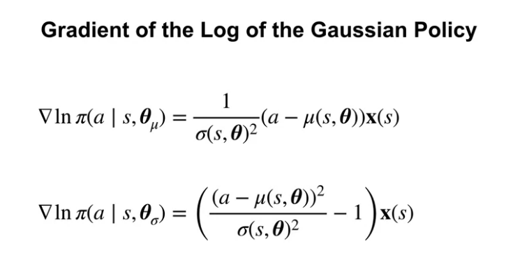

```python
# [Graded]

class ActorCriticSoftmaxAgent(BaseAgent):
    def __init__(self):
        self.rand_generator = None

        self.actor_u_step_size = None
        self.actor_v_step_size = None
        self.critic_step_size = None
        self.avg_reward_step_size = None

        self.tc = None

        self.avg_reward = None
        self.critic_w = None
        self.actor_u_w = None
        self.actor_v_w = None

        self.actions = None

        self.softmax_prob = None
        self.prev_tiles = None
        self.last_action = None

    def agent_init(self, agent_info={}):
        """Setup for the agent called when the experiment first starts.

        Set parameters needed to setup the semi-gradient TD(0) state aggregation agent.

        Assume agent_info dict contains:
        {
            "iht_size": int
            "num_tilings": int,
            "num_tiles": int,
            "actor_u_step_size": float,
            "actor_v_step_size": float,
            "critic_step_size": float,
            "avg_reward_step_size": float,
            "num_actions": int,
            "seed": int
        }
        """

        # set random seed for each run
#         self.rand_generator = np.random.RandomState(agent_info.get("seed"))
#         self.rand_normal_generator = np.random.normal(agent_info.get("seed"))
        np.random.seed(agent_info.get("seed"))
#         self.rand_normal


        iht_size = agent_info.get("iht_size")
        num_tilings = agent_info.get("num_tilings")
        num_tiles = agent_info.get("num_tiles")

        # initialize self.tc to the tile coder we created
        self.tc = PendulumTileCoder(iht_size=iht_size, num_tilings=num_tilings, num_tiles=num_tiles)

        # set step-size accordingly (we normally divide actor and critic step-size by num. tilings (p.217-218 of textbook))
        self.actor_u_step_size = agent_info.get("actor_u_step_size")/num_tilings
        self.actor_v_step_size = agent_info.get("actor_v_step_size")/num_tilings

        self.critic_step_size = agent_info.get("critic_step_size")/num_tilings
        self.avg_reward_step_size = agent_info.get("avg_reward_step_size")

#         self.actions = list(range(agent_info.get("num_actions")))

        # Set initial values of average reward, actor weights, and critic weights
        # We initialize actor weights to three times the iht_size.
        # Recall this is because we need to have one set of weights for each of the three actions.
        self.avg_reward = 0.0
        self.actor_u_w = np.zeros(iht_size)
        self.actor_v_w = np.zeros(iht_size)

        self.critic_w = np.zeros(iht_size)

#         self.softmax_prob = None
        self.prev_tiles = None
        self.last_action = None
        self.prev_u= None
        self.prev_v = None

    def agent_policy(self, active_tiles):
        """ policy of the agent
        Args:
            active_tiles (Numpy array): active tiles returned by tile coder

        Returns:
            The action selected according to the policy
        """

#         # compute softmax probability
#         softmax_prob = compute_softmax_prob(self.actor_w, active_tiles)

#         # Sample action from the softmax probability array
#         # self.rand_generator.choice() selects an element from the array with the specified probability
#         chosen_action = self.rand_generator.choice(self.actions, p=softmax_prob)

        u=np.sum(self.actor_u_w[active_tiles],axis=0)
        v=np.exp(np.sum(self.actor_v_w[active_tiles],axis=0))
        chosen_action = np.random.normal(u,v,1)

        self.prev_u = u
        self.prev_v = v


#         # save softmax_prob as it will be useful later when updating the Actor
#         self.softmax_prob = softmax_prob

        return chosen_action

    def agent_start(self, state):
        """The first method called when the experiment starts, called after
        the environment starts.
        Args:
            state (Numpy array): the state from the environment's env_start function.
        Returns:
            The first action the agent takes.
        """

        angle, ang_vel = state

        ### Use self.tc to get active_tiles using angle and ang_vel (2 lines)
        # set current_action by calling self.agent_policy with active_tiles
        # active_tiles = ?
        # current_action = ?

        ### START CODE HERE ###
        active_tiles = self.tc.get_tiles(angle, ang_vel)
        current_action = self.agent_policy(active_tiles)
        ### END CODE HERE ###

        self.last_action = current_action
        self.prev_tiles = np.copy(active_tiles)

        return self.last_action


    def agent_step(self, reward, state):
        """A step taken by the agent.
        Args:
            reward (float): the reward received for taking the last action taken
            state (Numpy array): the state from the environment's step based on
                                where the agent ended up after the
                                last step.
        Returns:
            The action the agent is taking.
        """

        angle, ang_vel = state

        ### Use self.tc to get active_tiles using angle and ang_vel (1 line)
        # active_tiles = ?
        ### START CODE HERE ###
        active_tiles = self.tc.get_tiles(angle, ang_vel)
        ### END CODE HERE ###

        ### Compute delta using Equation (1) (1 line)
        # delta = ?
        ### START CODE HERE ###
        delta = reward - self.avg_reward + self.critic_w[active_tiles].sum() - self.critic_w[self.prev_tiles].sum()
        ### END CODE HERE ###

        ### update average reward using Equation (2) (1 line)
        # self.avg_reward += ?
        ### START CODE HERE ###
        self.avg_reward += self.avg_reward_step_size * delta
        ### END CODE HERE ###

        # update critic weights using Equation (3) and (5) (1 line)
        # self.critic_w[self.prev_tiles] += ?
        ### START CODE HERE ###
        self.critic_w[self.prev_tiles] += self.critic_step_size * delta
        ### END CODE HERE ###

        # update actor weights using Equation (4) and (6)
        # We use self.softmax_prob saved from the previous timestep
        # We leave it as an exercise to verify that the code below corresponds to the equation.
#         for a in self.actions:
#             if a == self.last_action:
#                 self.actor_w[a][self.prev_tiles] += self.actor_step_size * delta * (1 - self.softmax_prob[a])
#             else:
#                 self.actor_w[a][self.prev_tiles] += self.actor_step_size * delta * (0 - self.softmax_prob[a])


        grad_u_w = (1/self.prev_v**2)*(self.last_action-self.prev_u)
        grad_v_w = (1/self.prev_v**2)*(self.last_action-self.prev_u)**2-1

        self.actor_u_w[self.prev_tiles]+=self.actor_u_step_size*delta*grad_u_w
        self.actor_v_w[self.prev_tiles]+=self.actor_v_step_size*delta*grad_v_w

        ### set current_action by calling self.agent_policy with active_tiles (1 line)
        # current_action = ?
        ### START CODE HERE ###
        current_action = self.agent_policy(active_tiles)
        ### END CODE HERE ###

        self.prev_tiles = active_tiles
        self.last_action = current_action

        return self.last_action


    def agent_message(self, message):
        if message == 'get avg reward':
            return self.avg_reward
```

```python
# Do not modify this cell!
## Test Code for agent_start()##

agent_info = {"iht_size": 4096,
              "num_tilings": 8,
              "num_tiles": 8,
              "actor_u_step_size": 1e-1,
              "actor_v_step_size": 1e-3,
              "critic_step_size": 1e-0,
              "avg_reward_step_size": 1e-2,
              "num_actions": 3,
              "seed": 99}

test_agent = ActorCriticSoftmaxAgent()
test_agent.agent_init(agent_info)

state = [-np.pi, 0.]

test_agent.agent_start(state)

print("agent active_tiles: {}".format(test_agent.prev_tiles))
print("agent selected action: {}".format(test_agent.last_action))
```

```
agent active_tiles: [0 1 2 3 4 5 6 7]
agent selected action: [-0.14235884]
```

**Expected output**:

[output not shown]

Run the following code to verify `agent_step()`

```python
# Do not modify this cell!

## Test Code for agent_step() ##
# Make sure agent_start() and agent_policy() are working correctly first.
# agent_step() should work correctly for other arbitrary state transitions in addition to this test case.

env_info = {"seed": 99}
agent_info = {"iht_size": 4096,
              "num_tilings": 8,
              "num_tiles": 8,
              "actor_u_step_size": 1e-1,
              "actor_v_step_size": 1e-3,
              "critic_step_size": 1e-0,
              "avg_reward_step_size": 1e-2,
              "num_actions": 3,
              "seed": 99}

test_env = PendulumEnvironment
test_agent = ActorCriticSoftmaxAgent

rl_glue = RLGlue(test_env, test_agent)
rl_glue.rl_init(agent_info, env_info)

# start env/agent
rl_glue.rl_start()
rl_glue.rl_step()

print("agent next_action: {}".format(rl_glue.agent.last_action))
print("agent avg reward: {}\n".format(rl_glue.agent.avg_reward))
print("agent first 10 values of actor mean weights: \n{}\n".format(rl_glue.agent.actor_u_w[:10]))
print("agent first 10 values of actor variance weights: \n{}\n".format(rl_glue.agent.actor_v_w[:10]))
print("agent first 10 values of critic weights: \n{}".format(rl_glue.agent.critic_w[:10]))
```

```
agent next_action: [2.16998934]
agent avg reward: -0.07926870499699024

agent first 10 values of actor mean weights:
[0.01410575 0.01410575 0.01410575 0.01410575 0.01410575 0.01410575
 0.01410575 0.01410575 0.         0.        ]

agent first 10 values of actor variance weights:
[0.00097078 0.00097078 0.00097078 0.00097078 0.00097078 0.00097078
 0.00097078 0.00097078 0.         0.        ]

agent first 10 values of critic weights:
[-0.99085881 -0.99085881 -0.99085881 -0.99085881 -0.99085881 -0.99085881
 -0.99085881 -0.99085881  0.          0.        ]
```

**Expected output**:

[output not shown]

## Section 3: Run Experiment

Now that we've implemented all the components of environment and agent, let's run an experiment! We want to see whether our agent is successful at learning the optimal policy of balancing the pendulum upright. We will plot total return over time, as well as the exponential average of the reward over time. We also do multiple runs in order to be confident about our results.

The experiment/plot code is provided in the cell below.

```python
# Do not modify this cell!

# Define function to run experiment
def run_experiment(environment, agent, environment_parameters, agent_parameters, experiment_parameters):

    rl_glue = RLGlue(environment, agent)

    # sweep agent parameters
    for num_tilings in agent_parameters['num_tilings']:
        for num_tiles in agent_parameters["num_tiles"]:
            for actor_u_ss in agent_parameters["actor_u_step_size"]:
                for critic_ss in agent_parameters["critic_step_size"]:
                    for avg_reward_ss in agent_parameters["avg_reward_step_size"]:
                        for actor_v_ss in agent_parameters["actor_v_step_size"]:

                            env_info = {}
                            agent_info = {"num_tilings": num_tilings,
                                          "num_tiles": num_tiles,
                                          "actor_u_step_size": actor_u_ss,
                                          "actor_v_step_size": actor_v_ss,
                                          "critic_step_size": critic_ss,
                                          "avg_reward_step_size": avg_reward_ss,
                                          "num_actions": agent_parameters["num_actions"],
                                          "iht_size": agent_parameters["iht_size"]}

                            # results to save
                            return_per_step = np.zeros((experiment_parameters["num_runs"], experiment_parameters["max_steps"]))
                            exp_avg_reward_per_step = np.zeros((experiment_parameters["num_runs"], experiment_parameters["max_steps"]))

                            # using tqdm we visualize progress bars
                            for run in tqdm(range(1, experiment_parameters["num_runs"]+1)):
                                env_info["seed"] = run
                                agent_info["seed"] = run

                                rl_glue.rl_init(agent_info, env_info)
                                rl_glue.rl_start()

                                num_steps = 0
                                total_return = 0.
                                return_arr = []

                                # exponential average reward without initial bias
                                exp_avg_reward = 0.0
                                exp_avg_reward_ss = 0.01
                                exp_avg_reward_normalizer = 0

                                while num_steps < experiment_parameters['max_steps']:
                                    num_steps += 1

                                    ## COMMENT THE FOLLOWING LINE "RENDER" FOR FASTER ITERATIONS
                                    # rl_glue.environment.env.render()
                                    rl_step_result = rl_glue.rl_step()

                                    reward = rl_step_result[0]
                                    total_return += reward
                                    return_arr.append(reward)
                                    avg_reward = rl_glue.rl_agent_message("get avg reward")

                                    exp_avg_reward_normalizer = exp_avg_reward_normalizer + exp_avg_reward_ss * (1 - exp_avg_reward_normalizer)
                                    ss = exp_avg_reward_ss / exp_avg_reward_normalizer
                                    exp_avg_reward += ss * (reward - exp_avg_reward)

                                    return_per_step[run-1][num_steps-1] = total_return
                                    exp_avg_reward_per_step[run-1][num_steps-1] = exp_avg_reward

                                rl_glue.environment.env.close()
    #                             pdb.set_trace()

                            if not os.path.exists('results_continuous'):
                                os.makedirs('results_continuous')

#                             save_name = "ActorCriticSoftmax_tilings_{}_tiledim_{}_actor_ss_{}_critic_ss_{}_avg_reward_ss_{}".format(num_tilings, num_tiles, actor_v_ss, critic_ss, avg_reward_ss)
#                             total_return_filename = "results_continuous/{}_total_return.npy".format(save_name)
#                             exp_avg_reward_filename = "results_continuous/{}_exp_avg_reward.npy".format(save_name)

                            legend_avg = "exp_avg_reward_per_step_meanSS_{}_varianceSS_{}".format(actor_u_ss,actor_v_ss)
                            legend_total = "total_reward_meanSS_{}_varianceSS_{}".format(actor_u_ss,actor_v_ss)

                            total_return_filename = "results_continuous/{}.npy".format(legend_avg)
                            exp_avg_reward_filename = "results_continuous/{}.npy".format(legend_total)

                            return_per_step=np.mean(return_per_step,axis=0)
                            exp_avg_reward_per_step=np.mean(exp_avg_reward_per_step,axis=0)
                            np.save(total_return_filename, return_per_step)
                            np.save(exp_avg_reward_filename, exp_avg_reward_per_step)
                            c=np.array([i for i in range(experiment_parameters['max_steps'])])

                            plt.plot(c,return_per_step,label=legend_avg)
                            plt.legend()
                            plt.show()
                            plt.figure()
                            plt.plot(c,exp_avg_reward_per_step,label=legend_total)
                            plt.legend()
                            plt.show()
```

## Section 3-1: Run Experiment with 32 tilings, size 8x8

We will first test our implementation using 32 tilings, of size 8x8. We saw from the earlier assignment using tile-coding that many tilings promote fine discrimination, and broad tiles allows more generalization. We conducted a wide sweep of meta-parameters in order to find the best meta-parameters for our Pendulum Swing-up task.

We swept over the following range of meta-parameters and the best meta-parameter is boldfaced below:

critic step-size: $\{\frac{2^{-4}}{32}, \frac{2^{-3}}{32}, \frac{2^{-2}}{32}, \frac{2^{-1}}{32}, \frac{2^{0}}{32}, \mathbf{\frac{2^{1}}{32}}, \frac{3}{32}, \frac{2^{2}}{32}\}$

avg reward step-size: $\{2^{-11}, 2^{-10} , 2^{-9} , 2^{-8}, 2^{-7}, \mathbf{2^{-6}}, 2^{-5}, 2^{-4}, 2^{-3}, 2^{-2}\}$

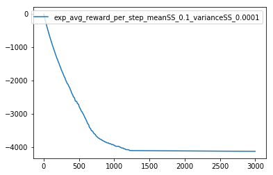

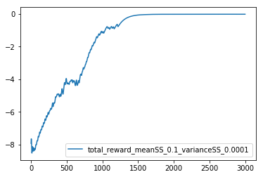

```python
experiment_parameters = {
    "max_steps" : 3000,
    "num_runs" : 5
}

# Environment parameters
environment_parameters = {}

# Agent parameters
# Each element is an array because we will be later sweeping over multiple values
# actor and critic step-sizes are divided by num. tilings inside the agent
agent_parameters = {
    "num_tilings": [32],
    "num_tiles": [8],
    "actor_u_step_size": [1e-1],
    "actor_v_step_size": [1e-4],
    "critic_step_size": [2**1],
    "avg_reward_step_size": [2**(-6)],
    "num_actions": 3,
    "iht_size": 4096
}


# variance step size = 1e-4 and actor step size = 5*1e-1 are are quite awesome

current_env = PendulumEnvironment
current_agent = ActorCriticSoftmaxAgent


run_experiment(current_env, current_agent, environment_parameters, agent_parameters, experiment_parameters)
# plot_script.plot_result(agent_parameters, 'results')
```

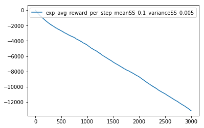

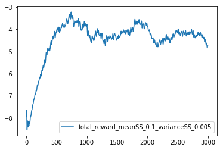

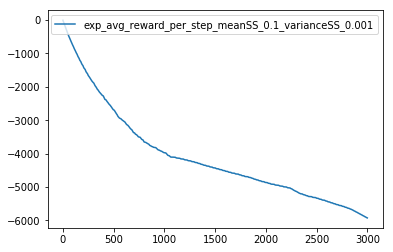

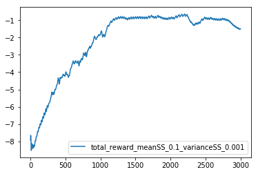

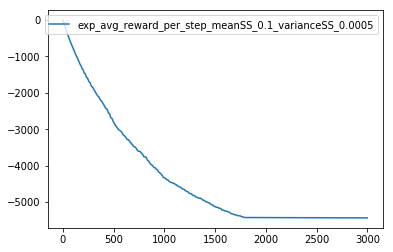

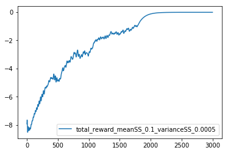

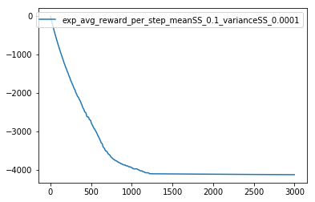

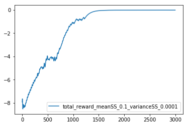

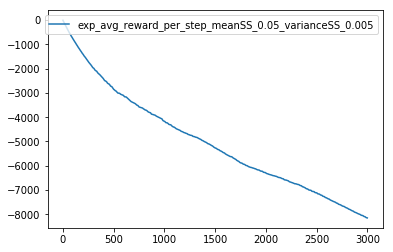

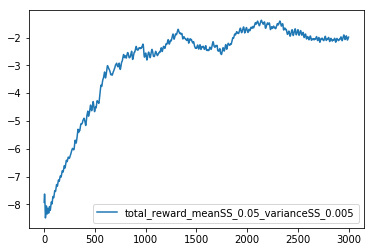

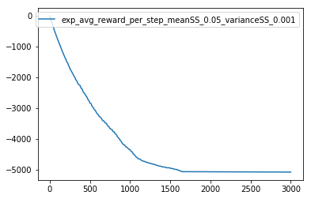

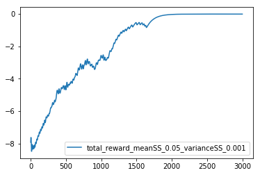

[28 more figures not shown]

```python
# importlib.reload(pendulum_env)
# from pendulum_env import PendulumEnvironment

#### Run Experiment

# Experiment parameters
experiment_parameters = {
    "max_steps" : 3000,
    "num_runs" : 5
}

# Environment parameters
environment_parameters = {}

# Agent parameters
# Each element is an array because we will be later sweeping over multiple values
# actor and critic step-sizes are divided by num. tilings inside the agent
agent_parameters = {
    "num_tilings": [32],
    "num_tiles": [8],
    "actor_u_step_size": [1e-1,5*1e-2,1e-2,5e-3,1e-4],
    "actor_v_step_size": [5e-3,1e-3,5e-4,1e-4],
    "critic_step_size": [2**1],
    "avg_reward_step_size": [2**(-6)],
    "num_actions": 3,
    "iht_size": 4096
}


# variance step size = 1e-4 and actor step size = 1e-1 are are quite awesome

current_env = PendulumEnvironment
current_agent = ActorCriticSoftmaxAgent


run_experiment(current_env, current_agent, environment_parameters, agent_parameters, experiment_parameters)
# plot_script.plot_result(agent_parameters, 'results')
```

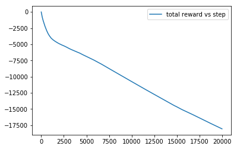

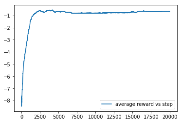

```python
a=np.load('results/ActorCriticSoftmax_tilings_32_tiledim_8_actor_ss_0.25_critic_ss_2_avg_reward_ss_0.015625_exp_avg_reward.npy')
b=np.load('results/ActorCriticSoftmax_tilings_32_tiledim_8_actor_ss_0.25_critic_ss_2_avg_reward_ss_0.015625_total_return.npy')
a_mean=np.mean(a,axis=0)
b_mean=np.mean(b,axis=0)

c=np.array([i for i in range(b_mean.shape[0])])

plt.plot(c,b_mean, label ='total reward vs step')
plt.legend()
plt.show()
plt.figure()
plt.plot(c,a_mean,  label ='average reward vs step')
plt.legend()
plt.show()
```